# Import Libraries

What we can observe is an intuitive trend. Besides the first few groups (customers with income from 0-10k and 10k-20k) where we have lower default rates probably due to low volumes, we observe a intuitive trend from 20k-30k onwards, where the default rate decreases as income increases.

```python
#Preparation of the data for the graph:
df_grouped=data.groupby([pd.cut(data["annual_inc"], np.arange(0, 1000.0+100000, 10000)),'loan_status']).size()
df_grouped1=df_grouped.groupby(level=0).apply(lambda x: x/x.sum() * 100).unstack(level='loan_status').reset_index()
df_grouped=df_grouped.groupby(level=0).apply(lambda x: x).unstack(level='loan_status').reset_index()
df_grouped['Total']=df_grouped['Charged Off'] + df_grouped['Fully Paid']
```

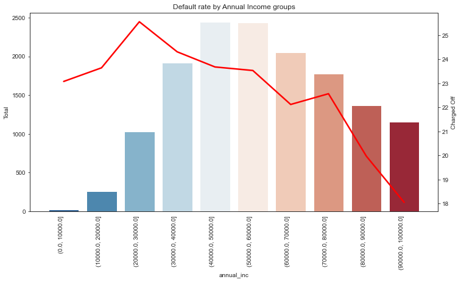

```python
#Graph:
sns.set_style('white')
df_grouped=df_grouped.dropna()
df_grouped1=df_grouped1.dropna()
fig, ax1 = plt.subplots(figsize=(12,6))
sns.barplot(data=df_grouped, x="annual_inc", y="Total", ax=ax1,palette='RdBu_r')
ax2 = ax1.twinx()
sns.lineplot(data=df_grouped1, x=df_grouped1["annual_inc"].astype(str), y="Charged Off",ax=ax2, color='r', linewidth=2.5).set(title='Default rate by Annual Income groups')
ax1.set_xticklabels(ax1.get_xticklabels(), rotation=90, horizontalalignment='right')
plt.show()
```

```python
#Preparation of data for the graph:
df_grouped = data.groupby(['pub_rec_bankruptcies','loan_status']).size()
df_grouped1=df_grouped.groupby(level=0).apply(lambda x: x/x.sum() * 100).unstack(level='loan_status').reset_index()
df_grouped=df_grouped.groupby(level=0).apply(lambda x: x).unstack(level='loan_status').reset_index()
df_grouped['Total']=df_grouped['Charged Off'] + df_grouped['Fully Paid']
```

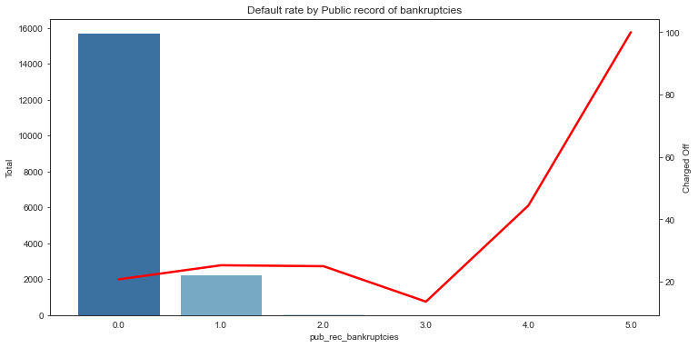

```python
#Graph:
sns.set_style('white')
fig, ax1 = plt.subplots(figsize=(12,6))
sns.barplot(data=df_grouped, x="pub_rec_bankruptcies", y="Total", ax=ax1,palette='RdBu_r')
ax2 = ax1.twinx()
sns.lineplot(data=df_grouped1, x="pub_rec_bankruptcies", y="Charged Off",ax=ax2, color='r', linewidth=2.5).set(title='Default rate by Public record of bankruptcies')
plt.show()
```

We now can look at another variable, employment length, `emp_length`.

Interestingly, the graph doesn't look that intuitive, as one may expect that the more years in employment the less the risk of defaulting. We do observe that the '10+ years' employment have a lower default rate, so it may be down to granularity here (e.g. there are not significant differences between someone who has worked 5 years and 6 years). If one were to use this variable in a model you could consider making this variable binary to make it work (e.g. have you worked more or less than 10 years?).

```python
#Preparation of data for the graph:
df_grouped = data.groupby(['emp_length','loan_status']).size()
df_grouped1=df_grouped.groupby(level=0).apply(lambda x: x/x.sum() * 100).unstack(level='loan_status').reset_index()
df_grouped=df_grouped.groupby(level=0).apply(lambda x: x).unstack(level='loan_status').reset_index()
df_grouped['Total']=df_grouped['Charged Off'] + df_grouped['Fully Paid']
df_grouped['emp_length'] = pd.Categorical(df_grouped['emp_length'],
                                   categories=['< 1 year','1 year','2 years',
                                              '3 years','4 years','5 years',
                                              '6 years','7 years','8 years',
                                              '9 years','10+ years'],
                                   ordered=True)
df_grouped1['emp_length'] = pd.Categorical(df_grouped1['emp_length'],
                                   categories=['< 1 year','1 year','2 years',
                                              '3 years','4 years','5 years',
                                              '6 years','7 years','8 years',
                                              '9 years','10+ years'],
                                   ordered=True)
```

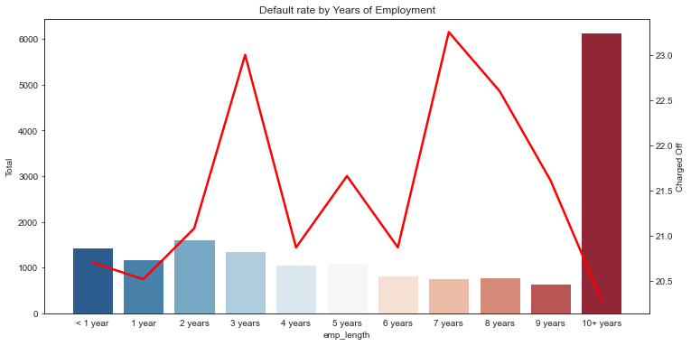

```python
fig, ax1 = plt.subplots(figsize=(12,6))
sns.set_style('white')
sns.barplot(data=df_grouped, x="emp_length", y="Total", ax=ax1, palette='RdBu_r')
ax2 = ax1.twinx()
sns.lineplot(data=df_grouped1, x="emp_length", y="Charged Off",ax=ax2, color='r', linewidth=2.5).set(title='Default rate by Years of Employment')
plt.show()
```

We now look at Loan amount, i.e. `loan_amnt`. The data shows smaller amounts (0 to 5k) get paid off, the same goes for larger loan amounts. This means that there is a "U" relationship between the target and this variable and is non-monotonic. This could also be a powerful predictor but as it has a oddly shaped relationship it could be one variable that requires some treatment (e.g. binning) before entering a model.

```python
df_grouped=data.groupby([pd.cut(data["loan_amnt"], np.arange(0, 1000.0+40000, 5000)),'loan_status']).size()
df_grouped1=df_grouped.groupby(level=0).apply(lambda x: x/x.sum() * 100).unstack(level='loan_status').reset_index()
df_grouped=df_grouped.groupby(level=0).apply(lambda x: x).unstack(level='loan_status').reset_index()
df_grouped['Total']=df_grouped['Charged Off'] + df_grouped['Fully Paid']
```

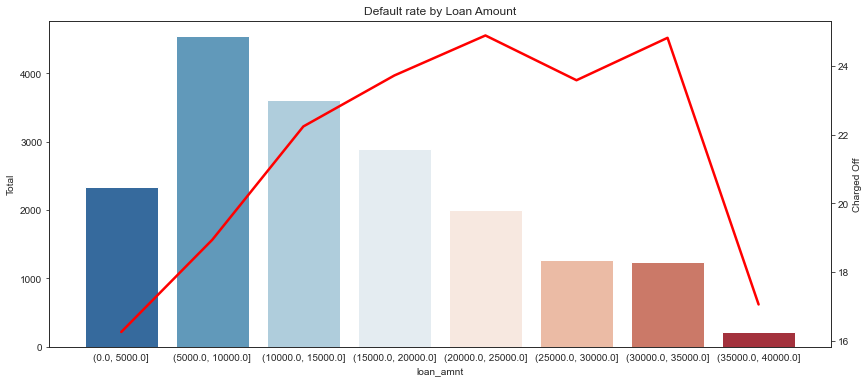

```python
df_grouped=df_grouped.dropna()
df_grouped1=df_grouped1.dropna()
fig, ax1 = plt.subplots(figsize=(14,6))
sns.set_style('white')
sns.barplot(data=df_grouped, x="loan_amnt", y="Total", ax=ax1, palette='RdBu_r')
ax2 = ax1.twinx()
sns.lineplot(data=df_grouped1, x=df_grouped1["loan_amnt"].astype(str), y="Charged Off",ax=ax2, color='r', linewidth=2.5).set(title='Default rate by Loan Amount')
plt.show()
```

An example on how to use the `loan_amnt` variable could be to create a variable an "Affordability" variable called `inc_ratio`. In this case we calculate the variable by dividing the loan amount by the annual income. We can observe that this variable looks quite promising and is strictly monotonic.

```python
data['inc_ratio'] = data['loan_amnt']/data['annual_inc']
df_grouped=data.groupby([pd.cut(data["inc_ratio"], np.arange(0, 0.1+0.5, 0.1)),'loan_status']).size()
df_grouped1=df_grouped.groupby(level=0).apply(lambda x: x/x.sum() * 100).unstack(level='loan_status').reset_index()
df_grouped=df_grouped.groupby(level=0).apply(lambda x: x).unstack(level='loan_status').reset_index()
df_grouped['Total']=df_grouped['Charged Off'] + df_grouped['Fully Paid']
```

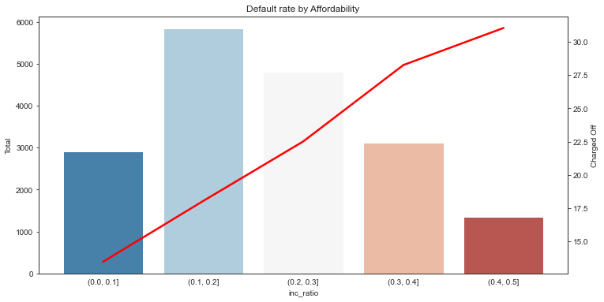

```python
df_grouped=df_grouped.dropna()
df_grouped1=df_grouped1.dropna()
fig, ax1 = plt.subplots(figsize=(12,6))
sns.set_style('white')
sns.barplot(data=df_grouped, x="inc_ratio", y="Total", ax=ax1,palette='RdBu_r')
ax2 = ax1.twinx()
sns.lineplot(data=df_grouped1, x=df_grouped1["inc_ratio"].astype(str), y="Charged Off",ax=ax2, color='r', linewidth=2.5).set(title='Default rate by Affordability')
plt.show()
```

# Building a Logistic Regression model

We now try to build a very rough Logistic Regression model with some variables. This is just a very quick example just to show how a logistic regression model is estimated.

We will only use a small subset of variables for the purpose of this example. Note that we transform the `loan_status` variable that is our target into a binary variable of zeros and ones (in case of Charge off). Also, in this example, we include a categorical variable such as `home ownership` but we will need to convert categorical features into dummy variables, otherwise our algorithm won't be able to directly take in those features as inputs.

```python
data['status'] = np.where(data['loan_status'] =='Charged Off', 1, 0)
home_ownership = pd.get_dummies(data['home_ownership'],drop_first=True)
```

```python
train=data[['status','inc_ratio','pub_rec_bankruptcies','num_tl_op_past_12m','open_acc']].fillna(0)
```

```python
train = pd.concat([train,home_ownership],axis=1)
```

In the next step we split our sample into a train and test dataset, so that we can assess the model we estimate on a separate sample.

```python
X_train, X_test, y_train, y_test = train_test_split(train.drop('status',axis=1),
                                                    train['status'], test_size=0.30,  stratify=train['status'],
                                                    random_state=101)
```

```python
logmodel = LogisticRegression(max_iter = 500)
logmodel.fit(X_train,y_train)
```

```
LogisticRegression(max_iter=500)
```

```python
predictions = logmodel.predict(X_test)
```

```python
print(classification_report(y_test,predictions))
```

```
              precision    recall  f1-score   support

           0       0.79      1.00      0.88      4276
           1       0.70      0.01      0.02      1163

    accuracy                           0.79      5439
   macro avg       0.74      0.51      0.45      5439
weighted avg       0.77      0.79      0.70      5439
```

```python
from sklearn.metrics import confusion_matrix
confusion_matrix = confusion_matrix(y_test, predictions)
print(confusion_matrix)
```

```
[[4270    6]
 [1149   14]]
```

```python
# If we just want to print out accuracy directly we can use:
print("Accuracy of the Logistic Regression model is",round(accuracy_score(y_test,predictions),2))
```

```
Accuracy of the Logistic Regression model is 0.79
```

# Building a Random Forest model

We will also try building a Random Forest model for comparison with the Logistic Regression model results.

This requires us to load some extra Python packages:

```
from sklearn.ensemble import RandomForestClassifier
from sklearn.metrics import accuracy_score
```

The `RandomForestClassifier` method is what we'll use to create our model. The `accuracy_score` function is use to compute the accuracy of the model.

Some details on Random Forest can be found at: https://machinelearningmastery.com/random-forest-ensemble-in-python/

For consistency, we will use the same subset of variables as the Logistic Regression model used. We'll also use the same split of training and test data.

```python
from sklearn.ensemble import RandomForestClassifier
from sklearn.metrics import accuracy_score
```

Set up our Random Forest model

```python
rfmodel = RandomForestClassifier(max_depth= 8, n_estimators=100, random_state=42)
```

Fit the Random Forest model to the training data:

```python
rfmodel.fit(X_train,y_train)
```

```
RandomForestClassifier(max_depth=8, random_state=42)
```

Get the predictions from the Random Forest Model

```python
predictions_rf = rfmodel.predict(X_test)
```

```python
# Print out the classification report
print(classification_report(y_test,predictions_rf))
```

```
              precision    recall  f1-score   support

           0       0.79      1.00      0.88      4276
           1       0.59      0.03      0.05      1163

    accuracy                           0.79      5439
   macro avg       0.69      0.51      0.47      5439
weighted avg       0.75      0.79      0.70      5439
```

Print the confusion matrix

```python
from sklearn.metrics import confusion_matrix
confusion_matrix = confusion_matrix(y_test, predictions_rf)
print(confusion_matrix)
```

```
[[4255   21]
 [1133   30]]
```

Accuracy of the Random Forest Model

```python
print("Accuracy of the Random Forest Model is",
      round(accuracy_score(y_test,predictions_rf),2))
```

```
Accuracy of the Random Forest Model is 0.79
```

Print out some information regarding which features were the most important in the Random Forest Model

```python
importances = rfmodel.feature_importances_

sorted_indices = np.argsort(importances)[::-1]
for i in sorted_indices:
    print("{0:25} {1:6}".format(X_train.columns[i],round(importances[i],4)))
```

```
inc_ratio                  0.506
open_acc                  0.1963
num_tl_op_past_12m        0.1594
pub_rec_bankruptcies      0.0617
RENT                      0.0381
MORTGAGE                  0.0259
OWN                       0.0127
OTHER                        0.0
```

# Compare Gini performance for both algorithms

**Gini coefficient**

The Gini coefficient is an industry standard measure of assessing the effectiveness of a scorecard in discriminating between good and bads.

Further details on how it's used and calculated :

https://towardsdatascience.com/clearly-explained-gini-coefficient-and-lorenz-curve-fe6f5dcdc07

https://www.thoughtco.com/calculate-the-gini-coefficient-1147711

```python
# Calculate probability outcome to feed into Gini function
log_proba = logmodel.predict_proba(X_test)[:, 1]
rf_proba = rfmodel.predict_proba(X_test)[:, 1]
```

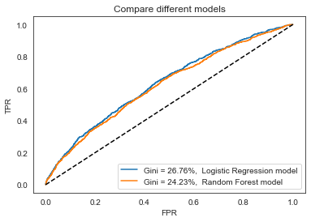

```python
# Compare all models on March 21' full apps sample
plt.title('Compare different models')
plot_roc(y_test, [(log_proba, 'Logistic Regression model'), (rf_proba, 'Random Forest model')])
```

# Kaggle

The data provided in this example is a subset of a much larger dataset on Kaggle. If you enjoyed this task and want to learn more we suggest you check out the full dataset with other potential methods for solving the problem here: https://www.kaggle.com/datasets/ethon0426/lending-club-20072020q1